# UD651 - Problem Set 3

Ivan Heneghan

9 January 2016

This is the project report for UD651 - Problem Set 3.

Load relevant libraries:

```r
library(data.table)
library(dplyr, warn.conflicts = FALSE)
library(ggplot2)
library(gridExtra)
library(lubridate)
library(plyr)
library(reshape2)
library(tidyr)
library(xlsx)
```

Load diamonds data set, and perform initial analysis:

```r
str(diamonds)
```

```
## Classes 'tbl_df', 'tbl' and 'data.frame':    53940 obs. of  10 variables:
##  $ carat  : num  0.23 0.21 0.23 0.29 0.31 0.24 0.24 0.26 0.22 0.23 ...
##  $ cut    : Ord.factor w/ 5 levels "Fair"<"Good"<..: 5 4 2 4 2 3 3 3 1 3 ...
##  $ color  : Ord.factor w/ 7 levels "D"<"E"<"F"<"G"<..: 2 2 2 6 7 7 6 5 2 5 ...
##  $ clarity: Ord.factor w/ 8 levels "I1"<"SI2"<"SI1"<..: 2 3 5 4 2 6 7 3 4 5 ...
##  $ depth  : num  61.5 59.8 56.9 62.4 63.3 62.8 62.3 61.9 65.1 59.4 ...
##  $ table  : num  55 61 65 58 58 57 57 55 61 61 ...
##  $ price  : int  326 326 327 334 335 336 336 337 337 338 ...
##  $ x      : num  3.95 3.89 4.05 4.2 4.34 3.94 3.95 4.07 3.87 4 ...
##  $ y      : num  3.98 3.84 4.07 4.23 4.35 3.96 3.98 4.11 3.78 4.05 ...
##  $ z      : num  2.43 2.31 2.31 2.63 2.75 2.48 2.47 2.53 2.49 2.39 ...
```

```r
head(diamonds)
```

```
## Source: local data frame [6 x 10]
##
##   carat       cut  color clarity depth table price     x     y     z
##   (dbl)    (fctr) (fctr)  (fctr) (dbl) (dbl) (int) (dbl) (dbl) (dbl)
## 1  0.23     Ideal      E     SI2  61.5    55   326  3.95  3.98  2.43
## 2  0.21   Premium      E     SI1  59.8    61   326  3.89  3.84  2.31
## 3  0.23      Good      E     VS1  56.9    65   327  4.05  4.07  2.31
## 4  0.29   Premium      I     VS2  62.4    58   334  4.20  4.23  2.63
## 5  0.31      Good      J     SI2  63.3    58   335  4.34  4.35  2.75
## 6  0.24 Very Good      J    VVS2  62.8    57   336  3.94  3.96  2.48
```

```r
colnames(diamonds)
```

```
##  [1] "carat"   "cut"     "color"   "clarity" "depth"   "table"   "price"
##  [8] "x"       "y"       "z"
```

```r
summary(diamonds)
```

```
##      carat               cut        color        clarity
##  Min.   :0.2000   Fair     : 1610   D: 6775   SI1    :13065
##  1st Qu.:0.4000   Good     : 4906   E: 9797   VS2    :12258
##  Median :0.7000   Very Good:12082   F: 9542   SI2    : 9194
##  Mean   :0.7979   Premium  :13791   G:11292   VS1    : 8171
##  3rd Qu.:1.0400   Ideal    :21551   H: 8304   VVS2   : 5066
##  Max.   :5.0100                     I: 5422   VVS1   : 3655
##                                     J: 2808   (Other): 2531
##      depth           table           price             x
##  Min.   :43.00   Min.   :43.00   Min.   :  326   Min.   : 0.000
##  1st Qu.:61.00   1st Qu.:56.00   1st Qu.:  950   1st Qu.: 4.710
##  Median :61.80   Median :57.00   Median : 2401   Median : 5.700
##  Mean   :61.75   Mean   :57.46   Mean   : 3933   Mean   : 5.731
##  3rd Qu.:62.50   3rd Qu.:59.00   3rd Qu.: 5324   3rd Qu.: 6.540
##  Max.   :79.00   Max.   :95.00   Max.   :18823   Max.   :10.740
##
##        y                z
##  Min.   : 0.000   Min.   : 0.000
##  1st Qu.: 4.720   1st Qu.: 2.910
##  Median : 5.710   Median : 3.530
##  Mean   : 5.735   Mean   : 3.539
##  3rd Qu.: 6.540   3rd Qu.: 4.040
##  Max.   :58.900   Max.   :31.800
##
```

Produce histogram of price of all the diamonds:

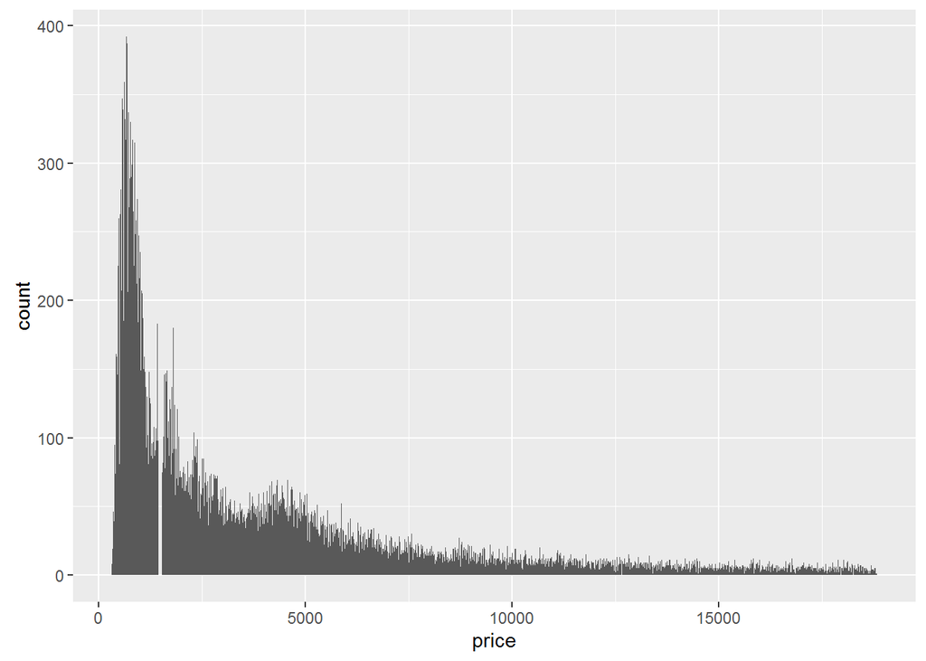

Summary of price information:

```r
summary(diamonds$price)
```

```
##    Min. 1st Qu.  Median    Mean 3rd Qu.    Max.
##     326     950    2401    3933    5324   18820
```

Counts:

```r
sum(diamonds$price < 500)
```

```
## [1] 1729
```

```r
sum(diamonds$price < 250)
```

```
## [1] 0
```

```r
sum(diamonds$price >= 15000)
```

```
## [1] 1656
```

| Exploring the largest peak in the histogram: |
| --- |

1. Look at the entire histogram:

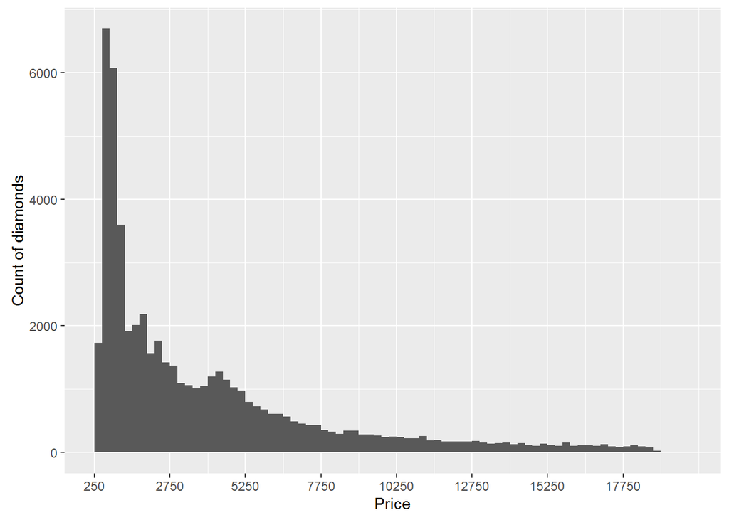

```r
qplot(x = price, data = diamonds, binwidth = 250,
      xlab = "Price", ylab = "Count of diamonds") +
  scale_x_continuous(limits = c(250, 20000), breaks = seq(250, 20000, 2500))
```

2. Zoom in on highest peak:

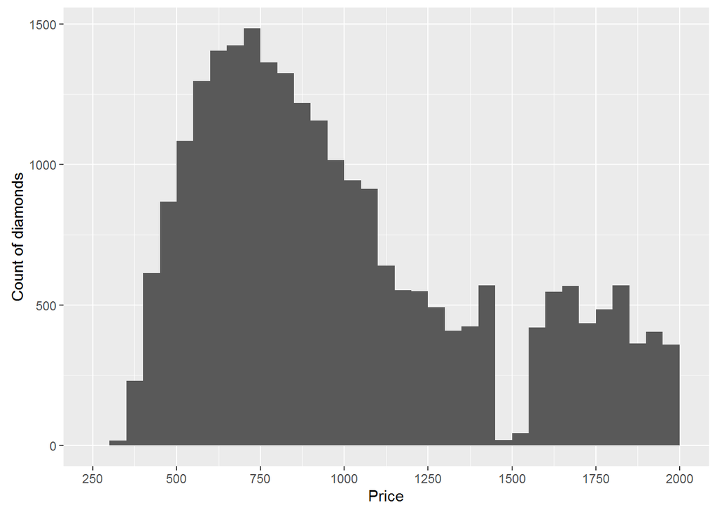

[output not shown]

```r
qplot(x = price, data = diamonds, binwidth = 50,
      xlab = "Price", ylab = "Count of diamonds") +
  scale_x_continuous(limits = c(250, 2000), breaks = seq(250, 2000, 250))
```

Histograms:

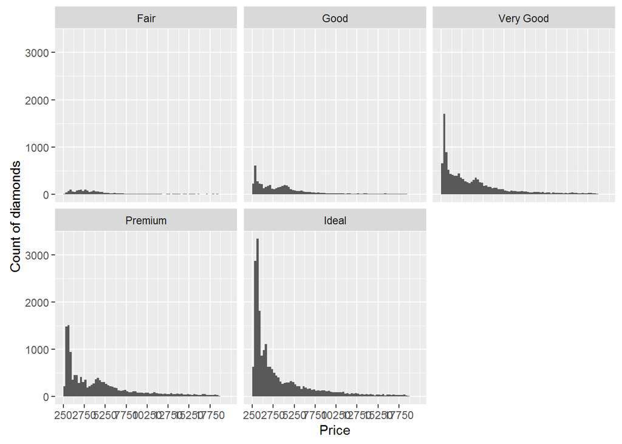

```r
qplot(x = price, data = diamonds, binwidth = 250,
      xlab = "Price", ylab = "Count of diamonds") +
  scale_x_continuous(limits = c(250, 20000), breaks = seq(250, 20000, 2500)) +
  facet_wrap(~cut)
```

Numerical analysis:

```r
by(diamonds$price, diamonds$cut, summary)
```

```
## diamonds$cut: Fair
##    Min. 1st Qu.  Median    Mean 3rd Qu.    Max.
##     337    2050    3282    4359    5206   18570
## --------------------------------------------------------
## diamonds$cut: Good
##    Min. 1st Qu.  Median    Mean 3rd Qu.    Max.
##     327    1145    3050    3929    5028   18790
## --------------------------------------------------------
## diamonds$cut: Very Good
##    Min. 1st Qu.  Median    Mean 3rd Qu.    Max.
##     336     912    2648    3982    5373   18820
## --------------------------------------------------------
## diamonds$cut: Premium
##    Min. 1st Qu.  Median    Mean 3rd Qu.    Max.
##     326    1046    3185    4584    6296   18820
## --------------------------------------------------------
## diamonds$cut: Ideal
##    Min. 1st Qu.  Median    Mean 3rd Qu.    Max.
##     326     878    1810    3458    4678   18810
```

Using Max due to rounding:

```r
by(diamonds$price, diamonds$cut, max)
```

```
## diamonds$cut: Fair
## [1] 18574
## --------------------------------------------------------
## diamonds$cut: Good
## [1] 18788
## --------------------------------------------------------
## diamonds$cut: Very Good
## [1] 18818
## --------------------------------------------------------
## diamonds$cut: Premium
## [1] 18823
## --------------------------------------------------------
## diamonds$cut: Ideal
## [1] 18806
```

Scales & multiple histograms:

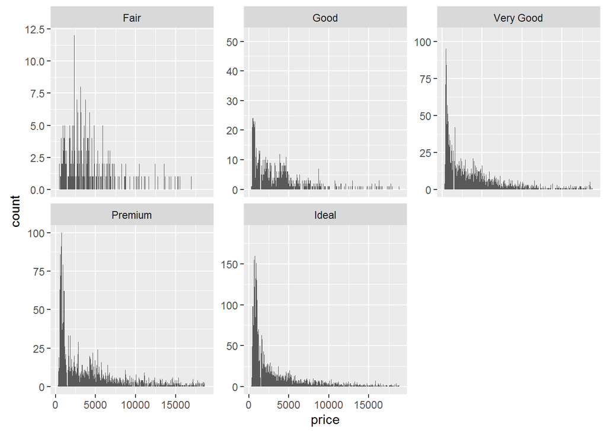

```r
qplot(x = price, data = diamonds, binwidth = 10) +
  facet_wrap(~cut, scales = "free_y")
```

Price per Carat by Cut:

[figure not shown]

```r
qplot(x = price/carat, data = diamonds, binwidth = 50) +
  facet_wrap(~cut, scales = "free_y") +
  scale_x_log10()
```

Box plot - price of diamonds, numerical summaries, and one other variable:

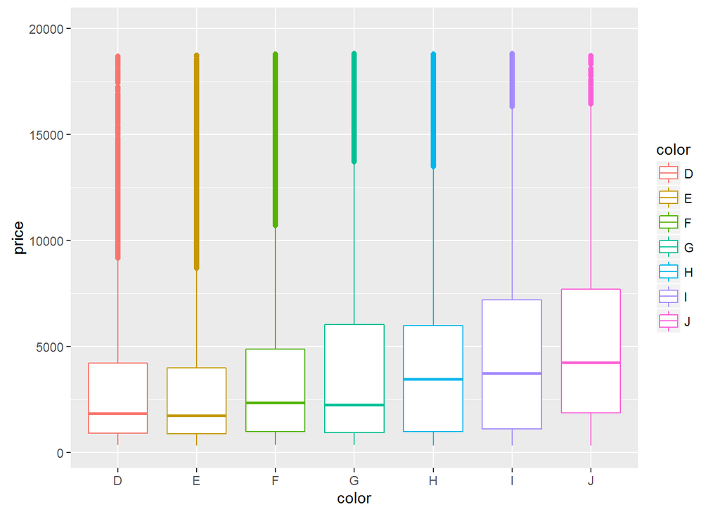

```r
qplot(x = color, y = price,
      data = diamonds,
      geom = "boxplot",
      color = color) +
  coord_cartesian(ylim = c(250, 20000))
```

IQR analysis:

```r
by(diamonds$price, diamonds$color, summary)
```

```
## diamonds$color: D
##    Min. 1st Qu.  Median    Mean 3rd Qu.    Max.
##     357     911    1838    3170    4214   18690
## --------------------------------------------------------
## diamonds$color: E
##    Min. 1st Qu.  Median    Mean 3rd Qu.    Max.
##     326     882    1739    3077    4003   18730
## --------------------------------------------------------
## diamonds$color: F
##    Min. 1st Qu.  Median    Mean 3rd Qu.    Max.
##     342     982    2344    3725    4868   18790
## --------------------------------------------------------
## diamonds$color: G
##    Min. 1st Qu.  Median    Mean 3rd Qu.    Max.
##     354     931    2242    3999    6048   18820
## --------------------------------------------------------
## diamonds$color: H
##    Min. 1st Qu.  Median    Mean 3rd Qu.    Max.
##     337     984    3460    4487    5980   18800
## --------------------------------------------------------
## diamonds$color: I
##    Min. 1st Qu.  Median    Mean 3rd Qu.    Max.
##     334    1120    3730    5092    7202   18820
## --------------------------------------------------------
## diamonds$color: J
##    Min. 1st Qu.  Median    Mean 3rd Qu.    Max.
##     335    1860    4234    5324    7695   18710
```

```r
IQR(subset(diamonds, color == "D" )$price)
```

```
## [1] 3302.5
```

```r
IQR(subset(diamonds, color == "J")$price)
```

```
## [1] 5834.5
```

Box plot - price per carat of diamonds across colors:

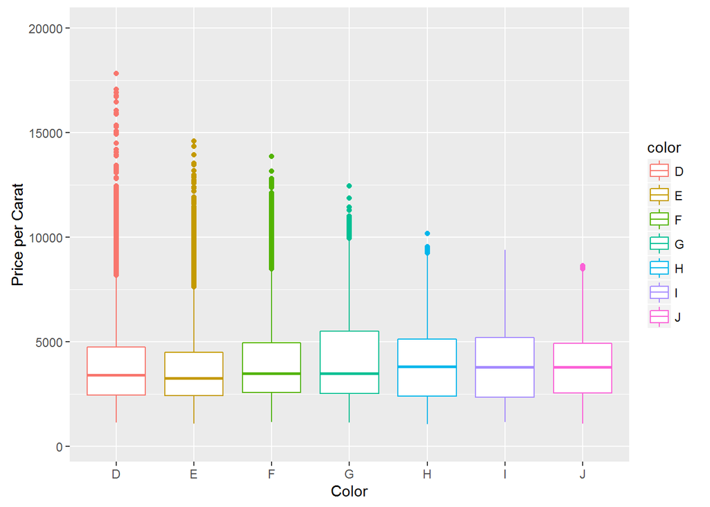

```r
qplot(x = color, y = price/carat ,
      data = diamonds,
      geom = "boxplot",
      xlab = "Color",
      ylab = "Price per Carat",
      color = color) +
  coord_cartesian(ylim = c(250, 20000))
```

Frequency polygon:

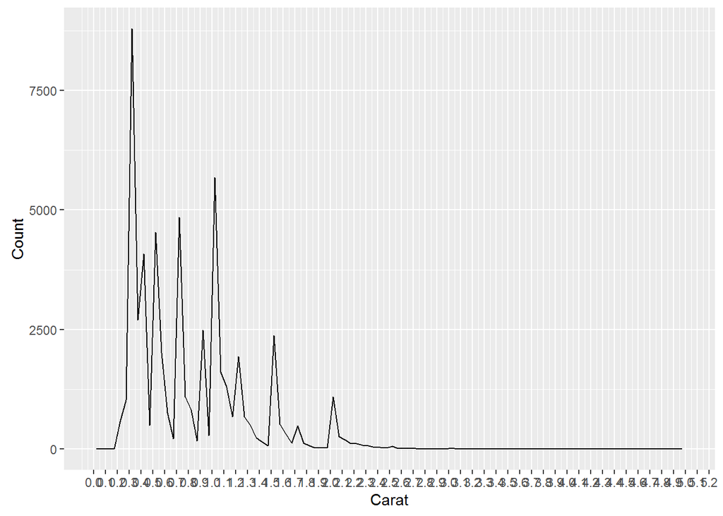

```r
qplot(x = carat, data = diamonds,
      binwidth = 0.05,
      xlab = "Carat",
      ylab = "Count",
      geom = "freqpoly") +
  scale_x_continuous(limits = c(0, 5), breaks = seq(0, 10, 0.1))
```

## Gapminder analysis - working hours per week

1. Import data:

```r
whpw <- read.xlsx("D:\\Foundations of Data Science\\Projects\\EDA - Facebook\\fods-ud651-ps3\\indicator_hours per week.xlsx", 1, stringsAsFactors = FALSE)
```

2. Rename first column to something more meaningful:

```r
names(whpw)[1] <- c("country")
```

3. Tidy data - gather into two column key-value pair:

```r
whpw <- whpw %>% gather(year, hours, -country)
```

4. Remove X’s from start of years:

```r
whpw$year <- gsub("X", "", whpw$year)
```

5. Create data table from the imported data:

```r
tbl_whpw <- tbl_df(whpw)
```

6. Initial viewing of data:

```r
str(tbl_whpw)
```

```
## Classes 'tbl_df', 'tbl' and 'data.frame':    1537 obs. of  3 variables:
##  $ country: chr  "Argentina" "Australia" "Austria" "Bangladesh" ...
##  $ year   : chr  "1980" "1980" "1980" "1980" ...
##  $ hours  : num  NA 34.6 NA NA NA ...
```

```r
head(tbl_whpw)
```

```
## Source: local data frame [6 x 3]
##
##      country  year    hours
##        (chr) (chr)    (dbl)
## 1  Argentina  1980       NA
## 2  Australia  1980 34.57885
## 3    Austria  1980       NA
## 4 Bangladesh  1980       NA
## 5    Belgium  1980       NA
## 6     Brazil  1980       NA
```

```r
colnames(tbl_whpw)
```

```
## [1] "country" "year"    "hours"
```

```r
summary(tbl_whpw)
```

```
##    country              year               hours
##  Length:1537        Length:1537        Min.   :25.92
##  Class :character   Class :character   1st Qu.:32.13
##  Mode  :character   Mode  :character   Median :34.24
##                                        Mean   :34.66
##                                        3rd Qu.:35.99
##                                        Max.   :56.21
##                                        NA's   :800
```

7. Analysis - boxplot showing progression over time:

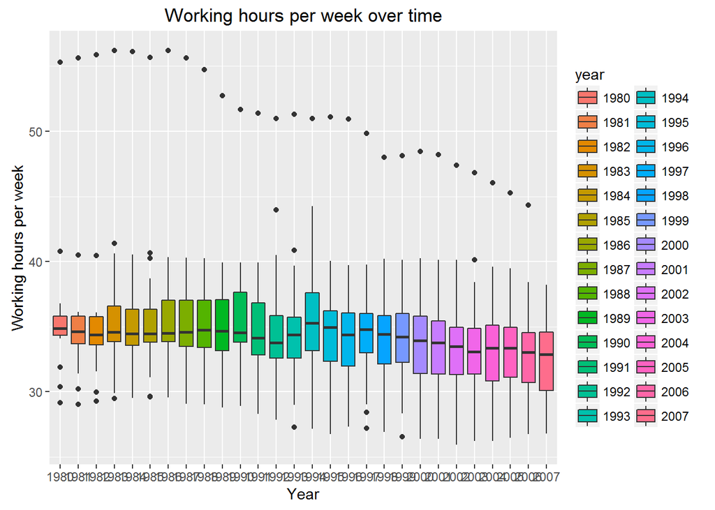

```r
ggplot(tbl_whpw[!is.na(whpw$hours),], aes(x = year, y = hours, fill = year)) +
  geom_boxplot() +
  xlab("Year") +
  ylab("Working hours per week") +
  ggtitle("Working hours per week over time")
```

8. Analysis - line graph:

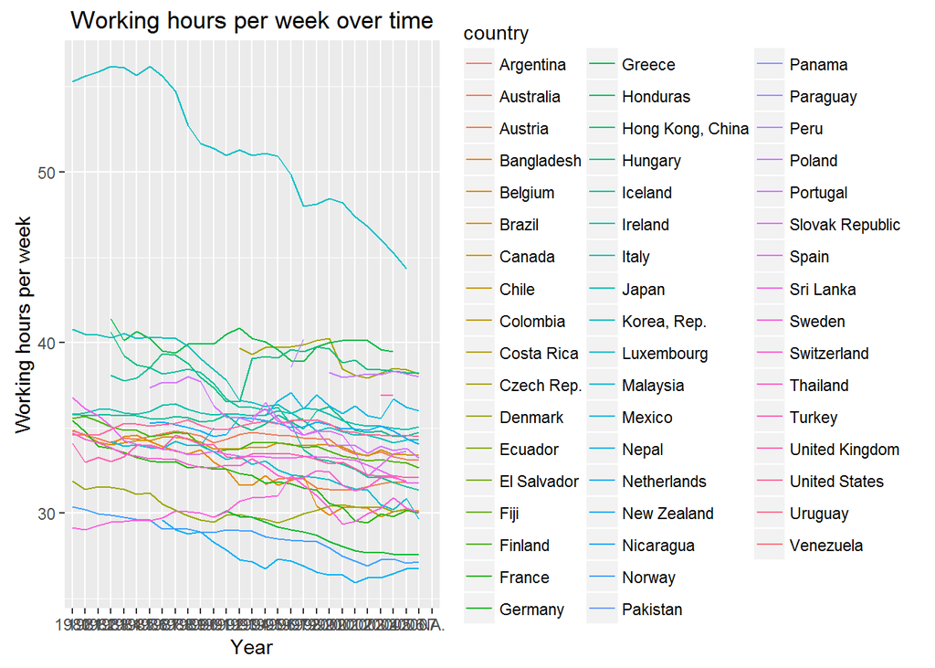

```r
ggplot(aes(x = year, y = hours, group = country, color = country), data = tbl_whpw, binwidth = 5) +
  geom_line() +
  xlab("Year") +
  ylab("Working hours per week") +
  ggtitle("Working hours per week over time")
```

9. Analysis - subsetting to look at countries with > 40 hours per week over entire time period:

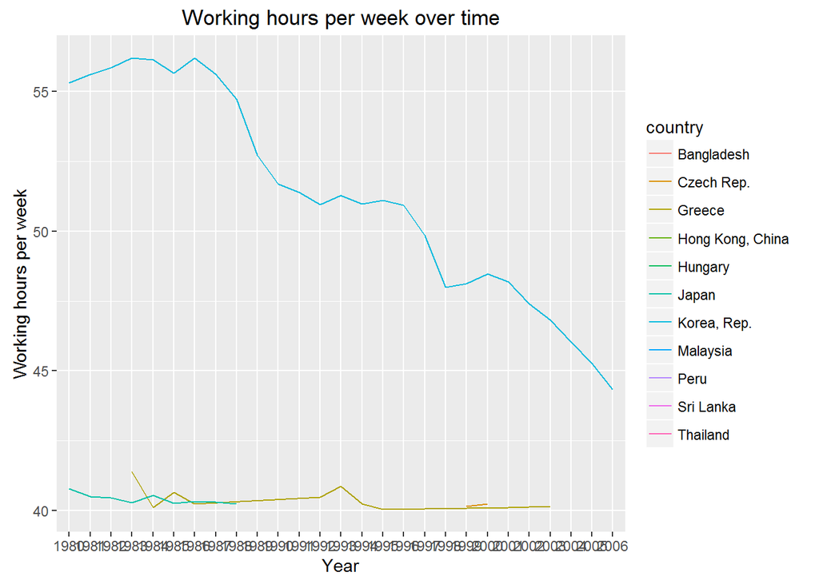

```r
ggplot(aes(x = year, y = hours, group = country, color = country), data = subset(tbl_whpw, hours > 40) , binwidth = 5) +
  geom_line() +
  xlab("Year") +
  ylab("Working hours per week") +
  ggtitle("Working hours per week over time")
```

10. Analysis - subsetting to look at countries with < 40 hours per week over entire time period:

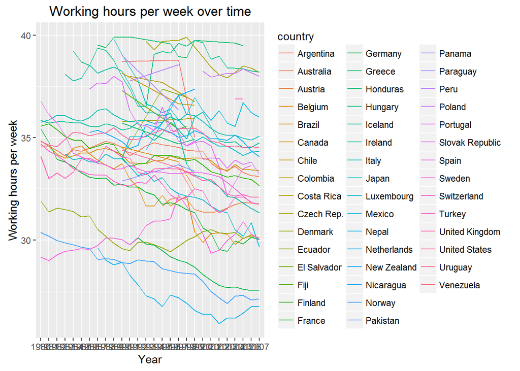

```r
ggplot(aes(x = year, y = hours, group = country, color = country), data = subset(tbl_whpw, hours < 40) , binwidth = 5) +
  geom_line() +
  xlab("Year") +
  ylab("Working hours per week") +
  ggtitle("Working hours per week over time")
```

11. Melting data to allow delta change calculation & histogram:

```r
tbl_whpw <- spread(tbl_whpw, year, hours)
```

12. Getting delta change for each country between 1990 and 2007:

```r
tbl_whpw$delta <- tbl_whpw$`2007` - tbl_whpw$`1990`
```

13. Analysis - Reviewing sumary of delta change:

```r
summary(tbl_whpw$delta)
```

```
##    Min. 1st Qu.  Median    Mean 3rd Qu.    Max.    NA's
## -6.8850 -2.9430 -1.5620 -1.9220 -0.7154  2.0080      33
```

14. Analysis - looking at histograms for 1990 and 2007:

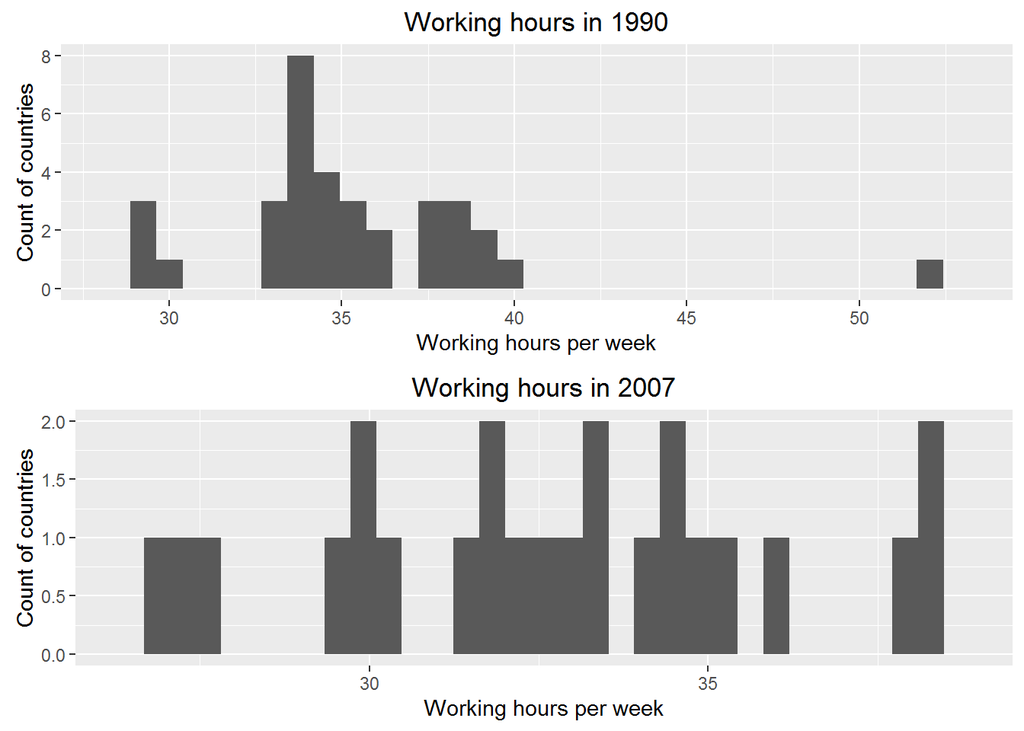

```r
g1 <- ggplot(aes(tbl_whpw$`1990`), data = tbl_whpw, binwidth = 1) +
  geom_histogram() +
  xlab("Working hours per week") +
  ylab("Count of countries") +
  ggtitle("Working hours in 1990")

g2 <- ggplot(aes(tbl_whpw$`2007`), data = tbl_whpw, binwidth = 1) +
  geom_histogram() +
  xlab("Working hours per week") +
  ylab("Count of countries") +
  ggtitle("Working hours in 2007")

grid.arrange(g1, g2, ncol = 1)
```

## Facebook friend analysis

1. Import data:

```r
birthdays <- read.csv("D:\\Foundations of Data Science\\Projects\\EDA - Facebook\\fods-ud651-ps3\\birthdaysExample.csv", stringsAsFactors = F)
```

2. Tidy data - use as.Date to create new column of dates:

```r
birthdays$betterDates <- as.Date(birthdays$dates, format = "%m/%d/%y")
```

2. Tidy data - Extract year, month, day, day of year:

```r
birthdays <- birthdays %>% mutate(year = year(birthdays$betterDates), month = month(birthdays$betterDates), day = day(birthdays$betterDates))
birthdays <- birthdays %>% mutate(dayOfYear = yday(birthdays$betterDates))
```

3. Viewing data:

```r
str(birthdays)
```

```
## 'data.frame':    1033 obs. of  6 variables:
##  $ dates      : chr  "11/25/14" "6/8/14" "9/12/14" "5/26/14" ...
##  $ betterDates: Date, format: "2014-11-25" "2014-06-08" ...
##  $ year       : num  2014 2014 2014 2014 2014 ...
##  $ month      : num  11 6 9 5 2 6 10 10 7 9 ...
##  $ day        : int  25 8 12 26 20 19 10 22 6 20 ...
##  $ dayOfYear  : num  329 159 255 146 51 170 283 295 187 263 ...
```

```r
head(birthdays)
```

```
##      dates betterDates year month day dayOfYear
## 1 11/25/14  2014-11-25 2014    11  25       329
## 2   6/8/14  2014-06-08 2014     6   8       159
## 3  9/12/14  2014-09-12 2014     9  12       255
## 4  5/26/14  2014-05-26 2014     5  26       146
## 5  2/20/14  2014-02-20 2014     2  20        51
## 6  6/19/14  2014-06-19 2014     6  19       170
```

```r
colnames(birthdays)
```

```
## [1] "dates"       "betterDates" "year"        "month"       "day"
## [6] "dayOfYear"
```

```r
summary(birthdays)
```

```
##     dates            betterDates              year          month
##  Length:1033        Min.   :2014-01-01   Min.   :2014   Min.   : 1.000
##  Class :character   1st Qu.:2014-03-28   1st Qu.:2014   1st Qu.: 3.000
##  Mode  :character   Median :2014-07-02   Median :2014   Median : 7.000
##                     Mean   :2014-06-30   Mean   :2014   Mean   : 6.474
##                     3rd Qu.:2014-09-28   3rd Qu.:2014   3rd Qu.: 9.000
##                     Max.   :2014-12-31   Max.   :2014   Max.   :12.000
##       day         dayOfYear
##  Min.   : 1.0   Min.   :  1.0
##  1st Qu.: 8.0   1st Qu.: 87.0
##  Median :16.0   Median :183.0
##  Mean   :15.7   Mean   :181.4
##  3rd Qu.:23.0   3rd Qu.:271.0
##  Max.   :31.0   Max.   :365.0
```

4. Analysis - number of people sharing my birthday (March 26th)? 2 people:

```r
count(subset(birthdays, month == "3" & day == "26"))
```

```
##     dates betterDates year month day dayOfYear freq
## 1 3/26/14  2014-03-26 2014     3  26        85    2
```

5. Analysis - which month has the most birthdays? March:

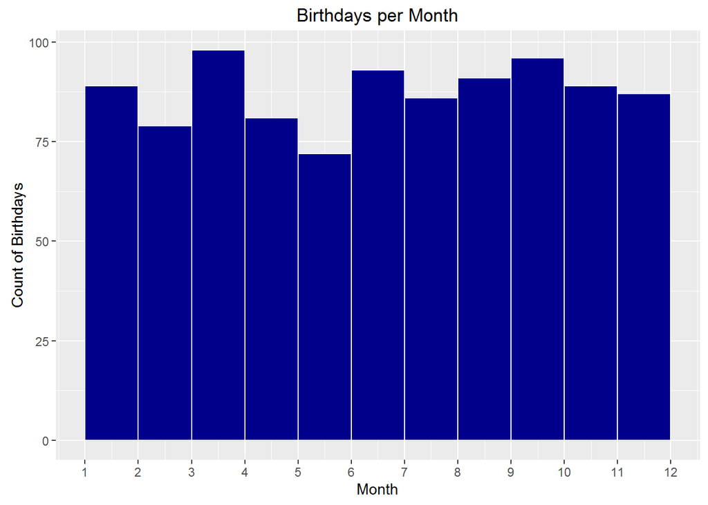

```r
ggplot(data = birthdays, aes(x = month)) +
    geom_histogram(binwidth = 1, color = "white", fill = "dark blue") +
    xlab("Month") +
    ylab("Count of Birthdays") +
    ggtitle("Birthdays per Month") +
  scale_x_continuous(limits = c(1, 12), breaks = seq(1, 12, 1))
```

6. Analysis - number of birthdays in each month?

```r
count(birthdays$month)
```

```
##     x freq
## 1   1   89
## 2   2   79
## 3   3   98
## 4   4   81
## 5   5   72
## 6   6   93
## 7   7   86
## 8   8   91
## 9   9   96
## 10 10   89
## 11 11   87
## 12 12   72
```

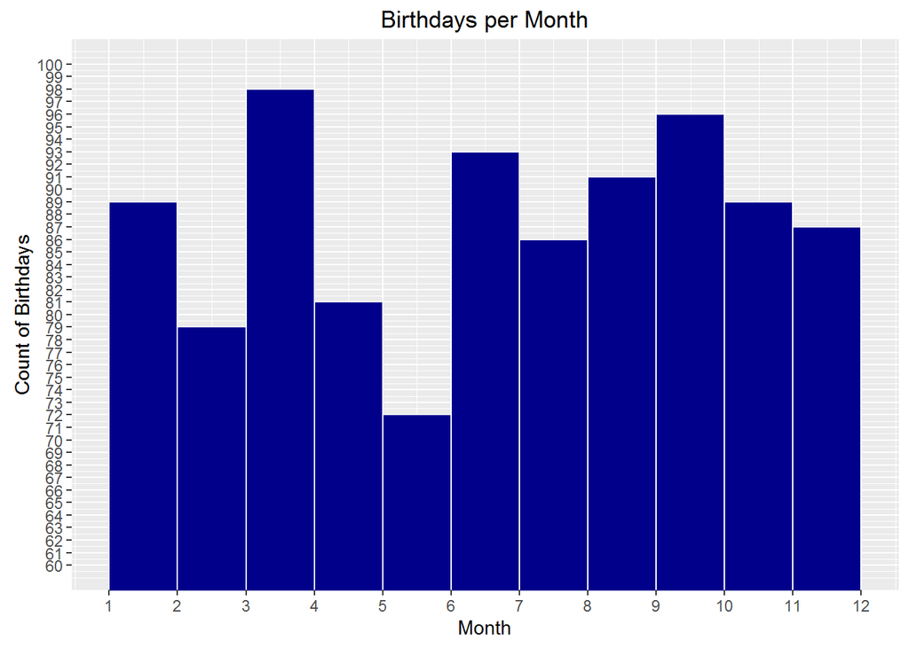

```r
ggplot(data = birthdays, aes(x = month)) +
  geom_histogram(binwidth = 1, color = "white", fill = "dark blue") +
  xlab("Month") +
  ylab("Count of Birthdays") +
  ggtitle("Birthdays per Month") +
  scale_x_continuous(limits = c(1, 12), breaks = seq(1, 12, 1)) +
  scale_y_continuous(breaks=seq(60, 100, 1)) +
  coord_cartesian(ylim=60:100)
```

7. Analysis - day of the year with most birthdays? 37th, 142nd and 197th days (Feb 6th, May 22nd and July 16th):

```r
birthdaysPerDay <- count(birthdays$dayOfYear)
birthdaysPerDay <- arrange(birthdaysPerDay, desc(freq))
head(birthdaysPerDay)
```

```
##     x freq
## 1  37    8
## 2 142    8
## 3 197    8
## 4  14    7
## 5  33    7
## 6  54    7
```

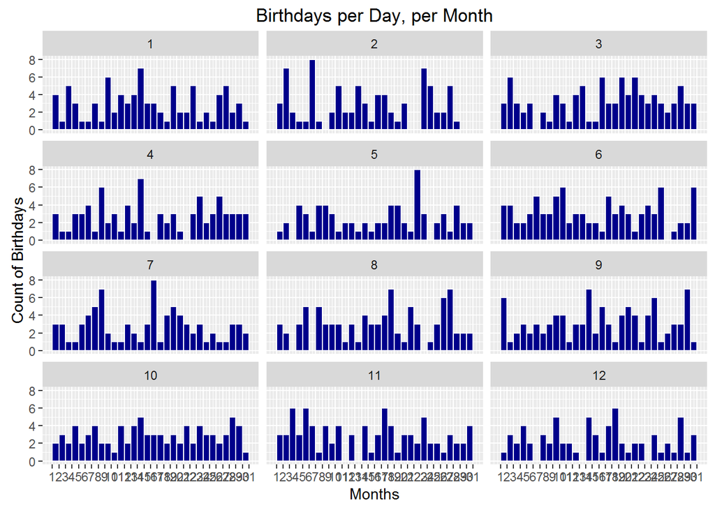

```r
ggplot(data = birthdays, aes(x = day)) +
  geom_histogram(binwidth = 1, color = "white", fill = "dark blue") +
  xlab("Months") +
  ylab("Count of Birthdays") +
  ggtitle("Birthdays per Day, per Month") +
  scale_x_continuous(limits = c(1, 31), breaks = seq(1, 31, 1)) +
  facet_wrap(~month, ncol = 3)
```

8. Analysis - friends with birthdays every day of the year? No, as there are gaps in the graph:

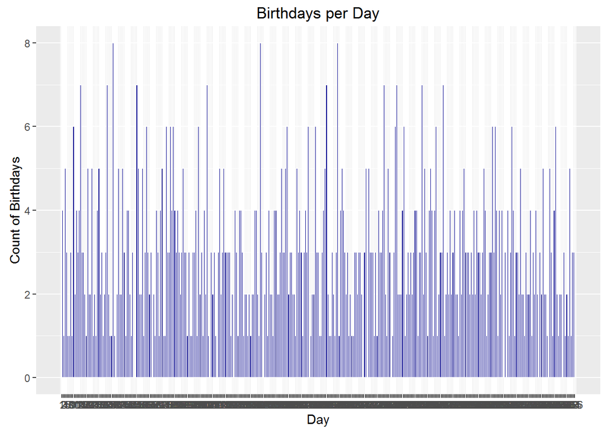

```r
ggplot(data = birthdays, aes(x = dayOfYear)) +
  geom_histogram(binwidth = 1, color = "white", fill = "dark blue") +
  xlab("Day") +
  ylab("Count of Birthdays") +
  ggtitle("Birthdays per Day") +
  scale_x_continuous(limits = c(1, 366), breaks = seq(1, 366, 1))
```